# PML_PredictionAssignment

Ben Marshall

26/12/2021

# Introduction

The goal of this project is to predict the manner in which 6 participants exercised as measured by various accelerometers on their body. This requires building a machine learning model from a training set of 19,622 observations and applying the model to predict on a sample of 20 observations. This report describes how I built my model, how I used cross validation, what I expected the out of sample error to be, and details why I made the choices I did along the way.

# Set up

## Import data and load required packages

First, I need to load in the required data and the r packages I will be using.

```r
library(caret)
library(ggplot2)
library(AppliedPredictiveModeling)
library(knitr)
library(data.table)
library(dplyr)
library(corrplot)
library(rattle)
download.file('https://d396qusza40orc.cloudfront.net/predmachlearn/pml-training.csv', 'pml-training.csv', method = 'curl')

download.file('https://d396qusza40orc.cloudfront.net/predmachlearn/pml-testing.csv', 'pml-testing.csv', method = 'curl')

training <- tbl_df(fread('pml-training.csv'))
validation <- tbl_df(fread('pml-testing.csv'))
```

## Data cleaning and pre-processing

There are 160 variables in both data sets. Some of which are mostly N/As, others contain metadata such as ID numbers, information which is not useful to the model, others have near zero variances. The following code removes all these variables from the model, reducing it to 54 variables

```r
#removes metadata
training <- training[, -(1:6)]
validation  <- validation[, -(1:6)]

#removes variables with near zero variance
nzv <- nearZeroVar(training, names = TRUE)
training <- select(training, -all_of(nzv))
validation  <- select(validation, -all_of(nzv))

#removes variables with >90% missing data
NAvariables <- sapply(training, function(x) mean(is.na(x))) > 0.90
training <- training[, NAvariables==FALSE]
validation  <- validation[, NAvariables==FALSE]

#ensure dependent variable is in the right format
training$classe <- as.factor(training$classe)
```

Highly correlated variables can introduce bias to the model. There are a number of ways to deal with this. First, Principal Components analysis can help to remove these correlated variables by creating a set of uncorrelated ‘factors’ that explain the majority of the variance. However, in this instance I’m just going to look for pairs of variables that correlate above 0.95, and discard one of the these using the findCorrelation function. This reduces the number of variables to 50.

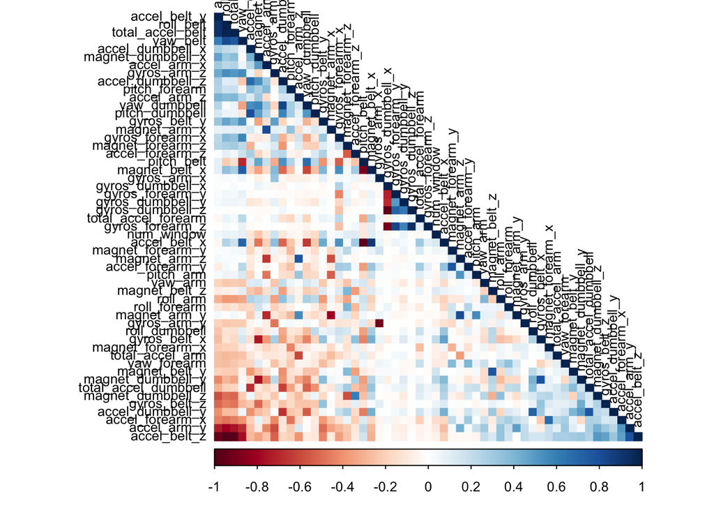

```r
corMatrix <- cor(training[, -54])
corrplot(corMatrix, order = "FPC", method = "color", type = "lower",
         tl.cex = 0.8, tl.col = rgb(0, 0, 0))
```

```r
exclVs <- findCorrelation(corMatrix, cutoff = 0.95, verbose = FALSE, names = T, exact = ncol(corMatrix) < 100)
training_nocorr <- select(training,-exclVs)
```

```
## Note: Using an external vector in selections is ambiguous.
## ℹ Use `all_of(exclVs)` instead of `exclVs` to silence this message.
## ℹ See <https://tidyselect.r-lib.org/reference/faq-external-vector.html>.
```

### Splitting the training set.

The methods chosen make use of cross-validation techniques via the trainControl function when building the models. However, to ensure accurate estimates of out of sample error, I chose to also break the training sample into a training set (70%) and a test set (30%) so that I could test the models generated on entirely ‘new’ data. The out of sample error can then be estimated as 1-accuracy of the models.

```r
set.seed(2651)
training_split <- createDataPartition(y = training_nocorr$classe,
                                   p = 0.7,
                                   list = FALSE)
training_set <- training_nocorr[training_split,]
test_set <- training_nocorr[-training_split,]
```

## Analysis

I chose to test three prediction models and to choose the one with the greatest accuracy / least out of sample error. The models chosen were: Classification Tree Method, Random Forest, and Generalised Boosted Model.

### Classification Tree Method

[figure not shown]

```r
set.seed(15423) # the same seed is set for each model to facilitate a fair comparison
trControl <- trainControl(method="cv", number=5)
ct_model <- train(classe~., method="rpart", data=training_set, trControl=trControl)
fancyRpartPlot(ct_model$finalModel)
```

```r
predict_tree <- predict(ct_model,newdata=test_set)
confMatClassTree <- confusionMatrix(test_set$classe,predict_tree)
confMatClassTree
```

```
## Confusion Matrix and Statistics
##
##           Reference
## Prediction    A    B    C    D    E
##          A 1404   35  235    0    0
##          B  183  380  574    0    2
##          C   10   38  978    0    0
##          D   78  170  629    0   87
##          E   94  224  420    0  344
##
## Overall Statistics
##
##                Accuracy : 0.5278
##                  95% CI : (0.5149, 0.5406)
##     No Information Rate : 0.4819
##     P-Value [Acc > NIR] : 1.048e-12
##
##                   Kappa : 0.4016
##
##  Mcnemar's Test P-Value : < 2.2e-16
##
## Statistics by Class:
##
##                      Class: A Class: B Class: C Class: D Class: E
## Sensitivity            0.7937  0.44864   0.3449       NA  0.79446
## Specificity            0.9344  0.84934   0.9843   0.8362  0.86464
## Pos Pred Value         0.8387  0.33363   0.9532       NA  0.31793
## Neg Pred Value         0.9133  0.90160   0.6176       NA  0.98147
## Prevalence             0.3006  0.14393   0.4819   0.0000  0.07358
## Detection Rate         0.2386  0.06457   0.1662   0.0000  0.05845
## Detection Prevalence   0.2845  0.19354   0.1743   0.1638  0.18386
## Balanced Accuracy      0.8640  0.64899   0.6646       NA  0.82955
```

The classification tree produced a model that was only 52.78% accurate (out of sample error of 47.22%).

### Random Forest Method

```r
set.seed(15423)
rf_control <- trainControl(method="cv", number=3, verboseIter=FALSE)
rf_model <- train(classe ~ ., data=training_set, method="rf", trControl=rf_control)
predict_rf <- predict(rf_model,newdata=test_set)
confMatRF <- confusionMatrix(test_set$classe,predict_rf)
confMatRF
```

```
## Confusion Matrix and Statistics
##
##           Reference
## Prediction    A    B    C    D    E
##          A 1674    0    0    0    0
##          B    3 1136    0    0    0
##          C    0    4 1022    0    0
##          D    0    0    2  962    0
##          E    0    0    0    2 1080
##
## Overall Statistics
##
##                Accuracy : 0.9981
##                  95% CI : (0.9967, 0.9991)
##     No Information Rate : 0.285
##     P-Value [Acc > NIR] : < 2.2e-16
##
##                   Kappa : 0.9976
##
##  Mcnemar's Test P-Value : NA
##
## Statistics by Class:
##
##                      Class: A Class: B Class: C Class: D Class: E
## Sensitivity            0.9982   0.9965   0.9980   0.9979   1.0000
## Specificity            1.0000   0.9994   0.9992   0.9996   0.9996
## Pos Pred Value         1.0000   0.9974   0.9961   0.9979   0.9982
## Neg Pred Value         0.9993   0.9992   0.9996   0.9996   1.0000
## Prevalence             0.2850   0.1937   0.1740   0.1638   0.1835
## Detection Rate         0.2845   0.1930   0.1737   0.1635   0.1835
## Detection Prevalence   0.2845   0.1935   0.1743   0.1638   0.1839
## Balanced Accuracy      0.9991   0.9979   0.9986   0.9988   0.9998
```

The Random Forest method produced very high accuracy rate of 99.81% accurate (out of sample error of 0.19%). This will be hard to beat.

### Generalised Boosting Method

```r
set.seed(15423)
gbm_control <- trainControl(method = "repeatedcv", number = 5, repeats = 1)
gbm_model <- train( classe ~.,
                  data = training_set,
                  method = "gbm",
                  trControl = gbm_control,
                  verbose = FALSE)
predict_gbm <- predict(gbm_model,newdata=test_set)
confMatGBM <- confusionMatrix(test_set$classe,predict_gbm)
confMatGBM
```

```
## Confusion Matrix and Statistics
##
##           Reference
## Prediction    A    B    C    D    E
##          A 1668    6    0    0    0
##          B    5 1114   14    6    0
##          C    0   15 1007    4    0
##          D    1    2   15  943    3
##          E    0    3    2    3 1074
##
## Overall Statistics
##
##                Accuracy : 0.9866
##                  95% CI : (0.9833, 0.9894)
##     No Information Rate : 0.2845
##     P-Value [Acc > NIR] : < 2.2e-16
##
##                   Kappa : 0.983
##
##  Mcnemar's Test P-Value : NA
##
## Statistics by Class:
##
##                      Class: A Class: B Class: C Class: D Class: E
## Sensitivity            0.9964   0.9772   0.9701   0.9864   0.9972
## Specificity            0.9986   0.9947   0.9961   0.9957   0.9983
## Pos Pred Value         0.9964   0.9781   0.9815   0.9782   0.9926
## Neg Pred Value         0.9986   0.9945   0.9936   0.9974   0.9994
## Prevalence             0.2845   0.1937   0.1764   0.1624   0.1830
## Detection Rate         0.2834   0.1893   0.1711   0.1602   0.1825
## Detection Prevalence   0.2845   0.1935   0.1743   0.1638   0.1839
## Balanced Accuracy      0.9975   0.9860   0.9831   0.9911   0.9978
```

The Generalized Boosted Model also produced very high accuracy of 98.66% accurate (out of sample error of 1.34%).

```r
validation_test_rf <- predict(rf_model,validation)
print(validation_test_rf)
```

```
##  [1] B A B A A E D B A A B C B A E E A B B B
## Levels: A B C D E
```